# Final Project: Guidance Document

Allen,Julian,Vishnu,Shweta

Due December 3, 2023

#Exploratory question: Does public restroom in a given neighborhood affect fecal matter appearance rates in said neighborhood?

#Datasets We took two data sets. One from ARCGIS San Francisco Poop map A scrapped using esri2sf on the arcgis service layer and bathroom from a wrangled csv using Excel from the San Francisco Government website.

```r
rm(list = ls())
library(rvest)
library(lubridate)
library(tidyverse)
library(DataComputing)
#data("SanFranPublicBathrooms.csv")
#We obtained the following from https://data.sfgov.org/City-Infrastructure/Map-of-Public-Water-Fountains/ne3b-nisa
sanfran=read.csv("SanFranPublicBathrooms.csv", header=TRUE)
head(sanfran)
```

|  | name | uid | resource_type | water_fountain | bottle_filler | jug_filler | dog_fountain | latitude | longitude | address | city | state | zip_code | park | access | public_access_hours_open | public_access_hours_close | public_access_days | notes | data_source | point | supervisor_district | analysis_neighborhood | data_as_of | data_loaded_at |
| --- | --- | --- | --- | --- | --- | --- | --- | --- | --- | --- | --- | --- | --- | --- | --- | --- | --- | --- | --- | --- | --- | --- | --- | --- | --- |
| 1 | Mission PG Clubhouse | 7.754602e+18 | restroom | 0 | 0 | 0 | 0 | 37.75940 | -122.4224 | 19th & Linda | San Francisco | CA | 94110 | Mission Playground | publicly_accessible | 08:00:00 | 20:00:00 | Daily | NA | rec | POINT (-122.422424583 37.759404762) | 9 | Mission | 2023/09/28 10:24:18 AM | 2023/11/01 11:30:01 AM |
| 2 | Golden Gate Park Kezar Pavilion | 5.429620e+18 | restroom | 0 | 0 | 0 | 0 | 37.76745 | -122.4541 | 755 Stanyan | San Francisco | CA | 94122 | Golden Gate Park - Section 1 | publicly_accessible | 08:00:00 | 20:00:00 | Daily | NA | rec | POINT (-122.454051248 37.767450638) | 5 | Golden Gate Park | 2023/09/28 10:24:18 AM | 2023/11/01 11:30:01 AM |
| 3 | Mission Pit Stop - 24th and Mission (JCDecaux) | 4.283604e+17 | restroom | 0 | 0 | 0 | 0 | 37.75218 | -122.4186 | 24th and Mission (JCDecaux) | San Francisco | CA | NA |  | publicly_accessible |  |  |  | NA | pit_stop | POINT (-122.4185771 37.7521752) | 9 | Mission | 2023/09/28 10:24:18 AM | 2023/11/01 11:30:01 AM |
| 4 | Haight Pit Stop - Buena Vista Avenue East & Haight Street | 6.328567e+18 | restroom | 0 | 0 | 0 | 0 | 37.77085 | -122.4404 | Buena Vista Avenue East & Haight Street | San Francisco | CA | NA |  | publicly_accessible |  |  |  | NA | pit_stop | POINT (-122.4403874 37.7708518) | 5 | Haight Ashbury | 2023/09/28 10:24:18 AM | 2023/11/01 11:30:01 AM |
| 5 | Adam Rogers Restrooms | 5.250842e+18 | restroom | 0 | 0 | 0 | 0 | 37.73089 | -122.3837 | Ingalls & Oakdale | San Francisco | CA | 94124 | Adam Rodgers Park | publicly_accessible | 08:00:00 | 20:00:00 | Daily | NA | rec | POINT (-122.383732841 37.730885219) | 10 | Bayview Hunters Point | 2023/09/28 10:24:18 AM | 2023/11/01 11:30:01 AM |
| 6 | Sandy Tatum Clubhouse | 9.307154e+17 | restroom | 0 | 0 | 0 | 0 | 37.72466 | -122.4937 | Lake Merced Blvd | San Francisco | CA | 94132 | Lake Merced Park | limited_access | 08:00:00 | 20:00:00 | Daily | NA | rec | POINT (-122.493654769 37.724664085) | 7 | Lakeshore | 2023/09/28 10:24:18 AM | 2023/11/01 11:30:01 AM |

```r
#We found the following github for scraping arcgis layers.
library(remotes)
#install_github("yonghah/esri2sf")
library("esri2sf")

#We found this layer from the pennstate arcgis directory. https://pennstate.maps.arcgis.com/home/item.html?id=f3c1738ad2024439b278baad2ae67a54#data
url <- "https://services.arcgis.com/QPnoxtBFXm6yYtyc/ArcGIS/rest/services/SanFranciscoPoopMap_WFL1/FeatureServer/2"
poop <- esri2sf(url, objectIds = paste(collapse = ","))
```

```
Layer Type: Feature Layer
Geometry Type: esriGeometryPoint
Service Coordinate Reference System: 3857
Output Coordinate Reference System: 4326
```

```r
head(sanfran)
```

|  | name | uid | resource_type | water_fountain | bottle_filler | jug_filler | dog_fountain | latitude | longitude | address | city | state | zip_code | park | access | public_access_hours_open | public_access_hours_close | public_access_days | notes | data_source | point | supervisor_district | analysis_neighborhood | data_as_of | data_loaded_at |
| --- | --- | --- | --- | --- | --- | --- | --- | --- | --- | --- | --- | --- | --- | --- | --- | --- | --- | --- | --- | --- | --- | --- | --- | --- | --- |
| 1 | Mission PG Clubhouse | 7.754602e+18 | restroom | 0 | 0 | 0 | 0 | 37.75940 | -122.4224 | 19th & Linda | San Francisco | CA | 94110 | Mission Playground | publicly_accessible | 08:00:00 | 20:00:00 | Daily | NA | rec | POINT (-122.422424583 37.759404762) | 9 | Mission | 2023/09/28 10:24:18 AM | 2023/11/01 11:30:01 AM |
| 2 | Golden Gate Park Kezar Pavilion | 5.429620e+18 | restroom | 0 | 0 | 0 | 0 | 37.76745 | -122.4541 | 755 Stanyan | San Francisco | CA | 94122 | Golden Gate Park - Section 1 | publicly_accessible | 08:00:00 | 20:00:00 | Daily | NA | rec | POINT (-122.454051248 37.767450638) | 5 | Golden Gate Park | 2023/09/28 10:24:18 AM | 2023/11/01 11:30:01 AM |
| 3 | Mission Pit Stop - 24th and Mission (JCDecaux) | 4.283604e+17 | restroom | 0 | 0 | 0 | 0 | 37.75218 | -122.4186 | 24th and Mission (JCDecaux) | San Francisco | CA | NA |  | publicly_accessible |  |  |  | NA | pit_stop | POINT (-122.4185771 37.7521752) | 9 | Mission | 2023/09/28 10:24:18 AM | 2023/11/01 11:30:01 AM |
| 4 | Haight Pit Stop - Buena Vista Avenue East & Haight Street | 6.328567e+18 | restroom | 0 | 0 | 0 | 0 | 37.77085 | -122.4404 | Buena Vista Avenue East & Haight Street | San Francisco | CA | NA |  | publicly_accessible |  |  |  | NA | pit_stop | POINT (-122.4403874 37.7708518) | 5 | Haight Ashbury | 2023/09/28 10:24:18 AM | 2023/11/01 11:30:01 AM |
| 5 | Adam Rogers Restrooms | 5.250842e+18 | restroom | 0 | 0 | 0 | 0 | 37.73089 | -122.3837 | Ingalls & Oakdale | San Francisco | CA | 94124 | Adam Rodgers Park | publicly_accessible | 08:00:00 | 20:00:00 | Daily | NA | rec | POINT (-122.383732841 37.730885219) | 10 | Bayview Hunters Point | 2023/09/28 10:24:18 AM | 2023/11/01 11:30:01 AM |
| 6 | Sandy Tatum Clubhouse | 9.307154e+17 | restroom | 0 | 0 | 0 | 0 | 37.72466 | -122.4937 | Lake Merced Blvd | San Francisco | CA | 94132 | Lake Merced Park | limited_access | 08:00:00 | 20:00:00 | Daily | NA | rec | POINT (-122.493654769 37.724664085) | 7 | Lakeshore | 2023/09/28 10:24:18 AM | 2023/11/01 11:30:01 AM |

##San Francisco table analysis We have important location information for geospatial analysis, but also redundant information such as date loaded, water fountains, and other public water descriptions unused in analysis. We will wrangle it later.

```r
head(poop)
```

```
Simple feature collection with 6 features and 14 fields
Geometry type: POINT
Dimension:     XY
Bounding box:  xmin: -122.4202 ymin: 37.75242 xmax: -122.3961 ymax: 37.79588
Geodetic CRS:  WGS 84
  OBJECTID  Date           RequestType
1       26 40175 Human or Animal Waste
2       27 43831 Human or Animal Waste
3       28 43965 Human or Animal Waste
4       29 43966 Human or Animal Waste
5       30 43966 Human or Animal Waste
6       31 43967 Human or Animal Waste
                                       Address          street
1        200 CAPP ST, SAN FRANCISCO, CA, 94110         CAPP ST
2     798 JACKSON ST, SAN FRANCISCO, CA, 94133      JACKSON ST
```

[output cut: 25 more lines]

##Poop table analysis We have a lot of redundant overlapping information such as neighborhood(neighborhood/Neighborhoods)+district(currentPD/PoliceDistrict). We will later define a function that will convert the 5 digit dates of the table into a day between 1-365 for the time period of July 2019 to June 2020. ————————————————————————–

```r
library(sf)
wrangled<-
  poop%>%
  mutate(URL=NULL,RequestType=NULL,source=NULL)%>%
  st_drop_geometry(df)

sanfranBR<-
  sanfran%>%
  mutate(uid=NULL, water_fountain=NULL, resource_type=NULL,bottle_filler=NULL,jug_filler=NULL, dog_fountain=NULL, notes=NULL, data_source=NULL,data_as_of=NULL,data_loaded_at=NULL)%>%
  st_drop_geometry(df)
```

#Wrangling We have two sets of wrangled datasets and later we defined some other subsets of data that still holds geoms. But the basis of our investigation focuses on geographical information and thus we remove information that involves unimportant to our special research question such as water fountains. We remove the geoms from the wrangled dataset to make joins easier since the geoms typically cause the datasets to be perceived as spatial data. However, we will maintain a subset to make the leaflet and compare location information. ————————————————————————–

```r
poopAtRestroom<-
  left_join(wrangled, sanfran, by=c('Neighborhood'='analysis_neighborhood'))
x <- wrangled %>%
  select(Neighborhood) %>%
  group_by(Neighborhood) %>%
  summarise(poop_count=n())

y <- sanfran %>%
  select(analysis_neighborhood) %>%
  group_by(analysis_neighborhood) %>%
  summarise(restroom_count=n())

joined_table <- x %>%
  full_join(y, join_by("Neighborhood" == "analysis_neighborhood"))

joined_table <- joined_table[!is.na(joined_table$Neighborhood),]
joined_table
```

| Neighborhood | poop_count | restroom_count |
| --- | --- | --- |
| Alamo Square | 61 | NA |
| Anza Vista | 42 | NA |
| Apparel City | 50 | NA |
| Aquatic Park / Ft. Mason | 23 | NA |
| Ashbury Heights | 23 | NA |
| Balboa Terrace | 1 | NA |
| Bayview | 340 | NA |
| Bernal Heights | 282 | 4 |
| Bret Harte | 61 | NA |
| Buena Vista | 117 | NA |

[output cut: 116 more lines]

#Join operation Before the information has been organized, we scale out the entirely of both datasets in one join in order to have a large scale analysis on the possible correlations between the two table. In doing so, we realized bathrooms tend to also differ by whether they are publically or selectively available for use.

```r
convert_num_to_date = function(date){
  hours_passed = (date %% 39630) * 2
  days = hours_passed %/% 24
  days
}

poop2 <- wrangled %>% mutate(dayReported=convert_num_to_date(wrangled$Date))

supervisor<-
    poop2%>%
    group_by(dayReported,supervisor)%>%
    summarise(count=n())%>%
    pivot_wider(names_from=supervisor, values_from = count, names_glue = "{.value}{supervisor}")
supervisor
```

| dayReported | count1 | count2 | count3 | count4 | count5 | count6 | count8 | count9 | count10 | count11 | count7 | count0 | countNA |
| --- | --- | --- | --- | --- | --- | --- | --- | --- | --- | --- | --- | --- | --- |
| 0 | 4 | 3 | 9 | 2 | 14 | 63 | 13 | 19 | 4 | NA | NA | NA | NA |
| 1 | NA | 1 | 9 | 4 | 15 | 68 | 9 | 22 | 2 | 1 | NA | NA | NA |
| 2 | NA | 2 | 6 | NA | 13 | 49 | 8 | 18 | 5 | 1 | NA | NA | NA |
| 3 | 3 | 2 | 10 | 1 | 12 | 18 | 18 | 26 | 3 | NA | 1 | NA | NA |
| 4 | NA | 3 | 20 | 2 | 11 | 34 | 13 | 27 | 7 | 1 | 1 | NA | NA |
| 5 | 1 | NA | 8 | NA | 8 | 32 | 6 | 14 | 4 | NA | NA | NA | NA |
| 6 | 2 | 2 | 11 | 1 | 6 | 37 | 8 | 21 | 5 | 1 | NA | NA | NA |
| 7 | NA | 5 | 14 | 1 | 4 | 42 | 5 | 25 | 3 | 1 | 2 | NA | NA |
| 8 | NA | 3 | 11 | NA | 10 | 25 | 6 | 27 | 4 | 2 | 2 | NA | NA |
| 9 | 2 | 5 | 11 | 2 | 10 | 25 | 4 | 20 | 7 | NA | NA | NA | NA |

[output cut: 258 more lines]

#Pivot wider We inspect the trends of supervisors for each day of the year in terms of finding excrement. This will appear in a graph later.

```r
for (i in 1:length(joined_table$Neighborhood)){
  case <- joined_table[i,]
  for (j in 1:length(case)){
    variable <- joined_table[i,j]
    if (is.na(variable) ){
      joined_table[i,j] <- 0
    }
  }
}
```

#VISUALIZATIONS

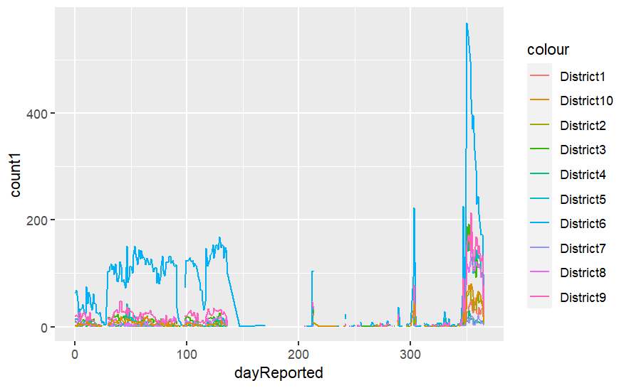

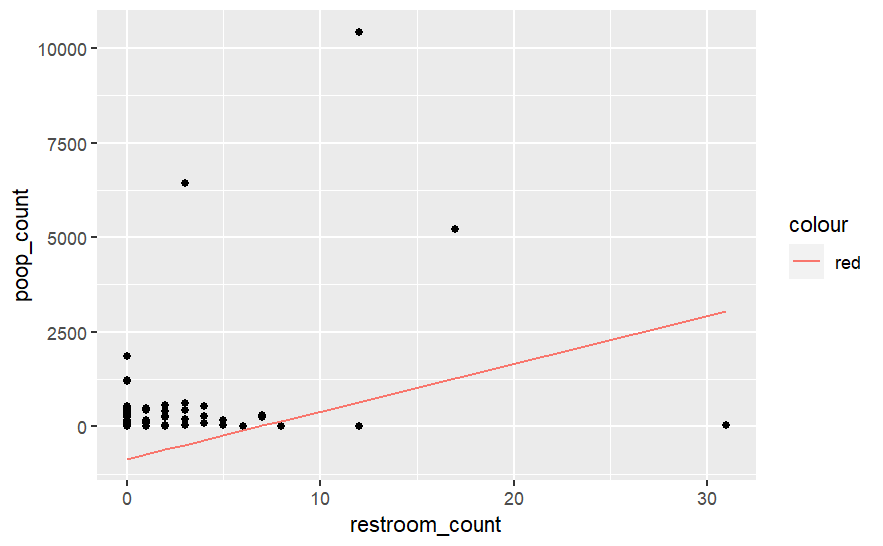

```r
b0 = out$par[1]
b1 = out$par[2]

reg_func = function(b0, b1, x){
  b0 + b1 * x
}

ggplot(joined_table) + geom_point(aes(x = restroom_count, y = poop_count)) +
  geom_line(aes(x = restroom_count, y = reg_func(b0, b1, restroom_count), color = "red"))
```

##Linear regression comparing restroom count and poop count. According to our effect, we find the restrooms in area tends to means more counts. In general, we should expect higher foot traffic in areas with higher bathrooms. However, the case seems to say there are cases where a neighborhood have few public bathrooms and they tend to have regular cases. However, it goes expontentially higher for places with a decent amount, but drops back down for when the instrastructure has a lot of bathrooms. Bathrooms have an effect that isn’t strictly linear, but rather seems to be an indictation of the nature of San Francisco infrastructure.

[figure not shown]

```r
wrangledA <- data.frame(Neighborhood = sample(c("A", "B", "C", "D"), 1000, replace = TRUE))

sanfranA <- data.frame(analysis_neighborhood = sample(c("A", "B", "C", "D"), 1000, replace = TRUE))

x <- wrangledA %>%
  select(Neighborhood) %>%
  group_by(Neighborhood) %>%
  summarise(poop_count = n())

y <- sanfranA %>%
  select(analysis_neighborhood) %>%
  group_by(analysis_neighborhood) %>%
  summarise(restroom_count = n())

joined_table <- x %>% full_join(y, by = c("Neighborhood" = "analysis_neighborhood"))


ggplot(joined_table, aes(x = Neighborhood)) +
  geom_bar(aes(y = poop_count, fill = "Poop Count"), stat = "identity", position = "dodge") +
  geom_bar(aes(y = restroom_count, fill = "Restroom Count"), stat = "identity", position = "dodge") +
  labs(title = "Poop and Restroom Counts in San Francisco Neighborhoods",
       x = "Neighborhood",
       y = "Count",
       fill = "Legend") +
  scale_fill_manual(values = c("Poop Count" = "#FF5733", "Restroom Count" = "#33B5E5")) +
  theme_minimal() +
  theme(legend.position = "top", legend.title = element_blank()) +
  scale_y_continuous(expand = expansion(mult = c(0.1, 0.2)))
```

```r
#devtools::install_github("rstudio/leaflet")
library(leaflet)
library(htmltools)
knitr::opts_chunk$set(echo = TRUE)

html <- list()
  html <- c(html,
            list(h3(paste0("Map")),
                leaflet() %>%
  addTiles() %>%
   addMarkers(clusterOptions = markerClusterOptions(), data=poop) %>%
   addCircleMarkers(radius=2, color="red", data=sanfran) %>%
   setView(-122.44, 37.76849, zoom=12)%>%
   addLegend(position = "bottomleft",
                         colors = c("red", "orange"),
                         labels = c("Public_Restrooms", "Poop Clusters are numbered"),
                         title = "Marker Categories")
                 )
            )
```

```
Assuming "longitude" and "latitude" are longitude and latitude, respectively
```

```r
tagList(html)
```

### Map

[interactive chart not shown]

#Leaflet In order to represent the data, we recreated a similar graph to the arcgis map, but as clusters and included bathrooms because their raw data is to produce purely points that can be used in rasanter functions whereas we want to use poops rather as a general point towards their relations to bathrooms. Calling back to our previous conclusions, we find that areas with very few bathrooms tend to have regular occurrences along the intersection of bathrooms. Furthermore we can find a large set of excrement adjacent to bathrooms in high density areas.

#Link to GITHUB Repo https://github.com/AG2025DS/Stat184FinalProject